# SVAP_Assignment_R2

SandeepKeswani

September 30, 2017

# Background

The rate at which urban air pollution has grown across India is alarming. A vast majority of cities are caught in the toxic web as air quality fails to meet health-based standards. Almost all cities are reeling under severe particulate pollution while newer pollutants like oxides of nitrogen and air toxics have begun to add to the public health challenge. Only a few mega cities where action has started show some improvement in air quality but in most cases the particulate levels are still unacceptably high. But medium and small sized towns and cities are witnessing phenomenal spurt in pollution as severe as or more than any mega city. AIr pollution is more severe in winter months mainly from October to December and much more in North India then SOuth India.

We have air quality data from 1990 to 2015 for all states and cities from https://www.kaggle.com/shrutibhargava94/india-air-quality-data , we have following parameters in dataset  
-stn-code  
-sampling_date  
-state  
-location  
-agency  
-type  
-so2  
-no2  
-rspm  
-spm  
-location_monitoring_station  
-pm2_5  
-date

Here are the permissible limits for these parameters https://www.dpcc.delhigovt.nic.in/airstd.htm

- SO2 Annual Average
  - 60 for Residential. Rural & other areas
  - 80 for Industrial area
  - 15 for Sensitive area
- NO2 Annual Average
  - 60 for Residential. Rural & other areas
  - 80 for Industrial area
  - 15 for Sensitive area
- SPM Annual Average
  - 140 for Residential. Rural & other areas
  - 360 for Industrial area
  - 70 for Sensitive area
- RSPM Annual Average
  - 60 for Residential. Rural & other areas
  - 120 for Industrial area
  - 50 for Sensitive area
- PM 2.5
  - 60 micrograms/cubic metre limit prescribed in the National Ambient Air Quality Standards of the Central Pollution Control Board

# Frame

We will look into following questions -Find out the top 3 polluting states in 2015  
-Analysis the trend for these top polluting states over the years since 1990  
-Analysis the trend for Bangalore as well over the past years  
-Predict the pollution levels for one of these top states for coming Diwali and winter months

```r
library(rvest)
library(tidyr)
library(dplyr)
```

```r
library(ggplot2)
library(reshape2)
library(lubridate)
```

# Acquire

We Have downloaded data from https://www.kaggle.com/shrutibhargava94/india-air-quality-data

```r
setwd("C:/Users/sandeep/OneDrive/Documents/BigData/SVAPAssignment/R2Assignment")
airquality=read.csv("data.csv")
str(airquality)
```

```
## 'data.frame':    435742 obs. of  13 variables:
##  $ stn_code                   : Factor w/ 745 levels "1","10","100",..: 60 61 62 60 61 62 60 61 62 61 ...
##  $ sampling_date              : Factor w/ 5485 levels "01-01-14","01-01-15",..: 5359 5359 5359 5422 5422 5422 5320 5320 5320 5435 ...
##  $ state                      : Factor w/ 37 levels "andaman-and-nicobar-islands",..: 2 2 2 2 2 2 2 2 2 2 ...
##  $ location                   : Factor w/ 304 levels "Agra","Ahmedabad",..: 115 115 115 115 115 115 115 115 115 115 ...
##  $ agency                     : Factor w/ 64 levels "Andhra Pradesh  Pollution Control Board",..: NA NA NA NA NA NA NA NA NA NA ...
##  $ type                       : Factor w/ 10 levels "Industrial","Industrial Area",..: 6 2 6 6 2 6 6 2 6 2 ...
##  $ so2                        : num  4.8 3.1 6.2 6.3 4.7 6.4 5.4 4.7 4.2 4 ...
##  $ no2                        : num  17.4 7 28.5 14.7 7.5 25.7 17.1 8.7 23 8.9 ...
##  $ rspm                       : num  NA NA NA NA NA NA NA NA NA NA ...
##  $ spm                        : num  NA NA NA NA NA NA NA NA NA NA ...
##  $ location_monitoring_station: Factor w/ 991 levels "A-1 Platters",..: NA NA NA NA NA NA NA NA NA NA ...
##  $ pm2_5                      : num  NA NA NA NA NA NA NA NA NA NA ...
##  $ date                       : Factor w/ 5067 levels "1987-01-01","1987-01-02",..: 214 214 214 215 215 215 216 216 216 217 ...
```

# Refine

–Quality and Consistency –Missing Value –Outlier –Remove unneeded variabes

We are doing following here  
1. Converting the date column to R date 2. As we have many values in column for type of area so we are reducing it to 3 types only which are Sensitive Area,Industrial Area and Residential and others  
3. Data Correction * Making the state as Punjab where city is Chandigarh  
* Correcting the two spelling for Bhubaneswar,Bhubaneshwar to Bhubaneswar  
* Correcting the two spelling for Yamuna Nagar,Yamunanagar to Yamunanagar  
4. Missing Value Treatment * Removing data for states “andaman-and-nicobar-islands”, “Lakshadweep”,“Tripura” as only NA is there

```r
#Converting the date object to R date
airquality$date=as.Date(airquality$date,'%Y-%m-%d')
summary(airquality)
```

```
##     stn_code       sampling_date               state
##  193    :  1428   19-03-15:   253   Maharashtra   : 60384
##  519    :  1280   12-02-15:   237   Uttar Pradesh : 42816
##  708    :  1273   19-02-15:   236   Andhra Pradesh: 26368
##  541    :  1270   05-11-15:   235   Punjab        : 25634
##  710    :  1269   11-11-15:   234   Rajasthan     : 25589
##  (Other):285145   (Other) :434544   Kerala        : 24728
##  NA's   :144077   NA's    :     3   (Other)       :230223
##        location
##  Guwahati  :  9984
##  Hyderabad :  9667
##  Delhi     :  8551
##  Chandigarh:  8520
##  Jaipur    :  7850
##  (Other)   :391167
##  NA's      :     3
##                                                                     agency
##  Maharashtra State Pollution Control Board                             : 27857
##  Uttar Pradesh State Pollution Control Board                           : 22686
##  Andhra Pradesh State Pollution Control Board                          : 19139
##  Himachal Pradesh State Environment Proection & Pollution Control Board: 15287
##  Punjab State Pollution Control Board                                  : 15232
##  (Other)                                                               :186060
##  NA's                                                                  :149481
##                                  type             so2
##  Residential, Rural and other Areas:179014   Min.   :  0.00
##  Industrial Area                   : 96091   1st Qu.:  5.00
##  Residential and others            : 86791   Median :  8.00
##  Industrial Areas                  : 51747   Mean   : 10.83
##  Sensitive Area                    :  8980   3rd Qu.: 13.70
##  (Other)                           :  7726   Max.   :909.00
##  NA's                              :  5393   NA's   :34646
##       no2              rspm             spm
##  Min.   :  0.00   Min.   :   0.0   Min.   :   0.0
##  1st Qu.: 14.00   1st Qu.:  56.0   1st Qu.: 111.0
##  Median : 22.00   Median :  90.0   Median : 187.0
##  Mean   : 25.81   Mean   : 108.8   Mean   : 220.8
##  3rd Qu.: 32.20   3rd Qu.: 142.0   3rd Qu.: 296.0
##  Max.   :876.00   Max.   :6307.0   Max.   :3380.0
##  NA's   :16233    NA's   :40222    NA's   :237387
##                                                location_monitoring_station
##  Regional Office                                             :  6261
##  Paonta Sahib                                                :  1599
##  Head Office, Bamunimaidan, Guwahati                         :  1327
##  ITI Building, Gopinath Nagar, Guwahati                      :  1280
##  Bank of Baroda Building, Near Pimpri-Chinchwad M.C. Building:  1273
##  (Other)                                                     :396511
##  NA's                                                        : 27491
##      pm2_5             date
##  Min.   :  3.0    Min.   :1987-01-01
##  1st Qu.: 24.0    1st Qu.:2007-07-03
##  Median : 32.0    Median :2010-11-12
##  Mean   : 40.8    Mean   :2010-01-11
##  3rd Qu.: 46.0    3rd Qu.:2013-09-07
##  Max.   :504.0    Max.   :2015-12-31
##  NA's   :426428   NA's   :7
```

```r
#Making the type generic to 3 only which are Sensitive Area,Industrial Area and Residential and others
airquality$type[airquality$type %in% c("Sensitive","Sensitive Areas")]="Sensitive Area"
airquality$type[airquality$type %in% c("Industrial","Industrial Areas")] <-"Industrial Area"
airquality$type[airquality$type %in% c("Residential","Residential, Rural and other Areas","RIRUO")] <-"Residential and others"
#Correcting the states and cities where there is multiple data
airquality$state[airquality$location=='Chandigarh']='Punjab'
unique(airquality$state)
```

```
##  [1] Andhra Pradesh              Arunachal Pradesh
##  [3] Assam                       Bihar
##  [5] Punjab                      Chhattisgarh
##  [7] Dadra & Nagar Haveli        Daman & Diu
##  [9] Delhi                       Goa
## [11] Gujarat                     Haryana
## [13] Himachal Pradesh            Jammu & Kashmir
## [15] Jharkhand                   Karnataka
## [17] Kerala                      Madhya Pradesh
## [19] Maharashtra                 Manipur
## [21] Meghalaya                   Mizoram
## [23] Nagaland                    Odisha
## [25] Puducherry                  Rajasthan
## [27] Sikkim                      Tamil Nadu
## [29] Telangana                   Uttar Pradesh
## [31] Uttarakhand                 Uttaranchal
## [33] West Bengal                 andaman-and-nicobar-islands
## [35] Lakshadweep                 Tripura
## 37 Levels: andaman-and-nicobar-islands ... West Bengal
```

```r
airquality$location[airquality$location=='Bhubaneshwar']='Bhubaneswar'
airquality$location[airquality$location=='Yamuna Nagar']='Yamunanagar'
#Removing un-needed data where only NA is there
airquality=airquality%>%filter(!state %in% c("andaman-and-nicobar-islands", "Lakshadweep","Tripura"))
```

# Transform,Explore and Model

## Transform and Model

```r
airquality$date=as.POSIXct(airquality$date)
airquality$year=year(airquality$date)
airquality$month=month(airquality$date)
#Find top polluting states in 2015 and then find out the trend for them from 1990 to 2015
#As delhi comes in all of these top list lets analysis trend in delhi separately
by_state_wise_2015 =airquality%>%filter(date>'2015-01-01')%>%group_by(state)%>%summarise(Avg_So2=mean(so2,na.rm=TRUE),
                                                  Avg_No2=mean(no2,na.rm=TRUE),
                                                  Avg_PM2_5=mean(pm2_5,na.rm=TRUE),
                                                  Avg_Rspm=mean(rspm,na.rm=TRUE),
                                                  Avg_Spm= mean(spm,na.rm=TRUE))
```

## Explore

- We will not be plotting SPM as SPM is NA for 2015 data

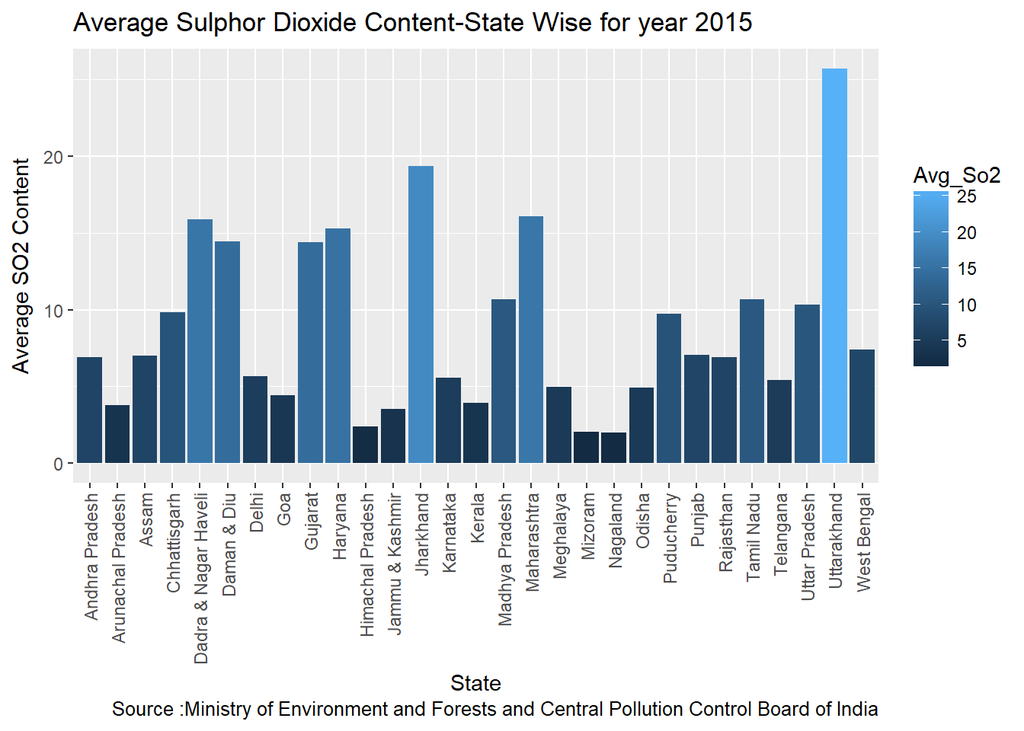

```r
ggplot(by_state_wise_2015,aes(x=state,y=Avg_So2,fill=Avg_So2)) +
   geom_bar(stat="identity")+
  theme(axis.text.x=element_text(angle=90,hjust=1,vjust=0.5)) +
  ggtitle("Average Sulphor Dioxide Content-State Wise for year 2015") +
  xlab(label="State") +
  ylab(label="Average SO2 Content") +
  labs(caption="Source :Ministry of Environment and Forests and Central Pollution Control Board of India")
```

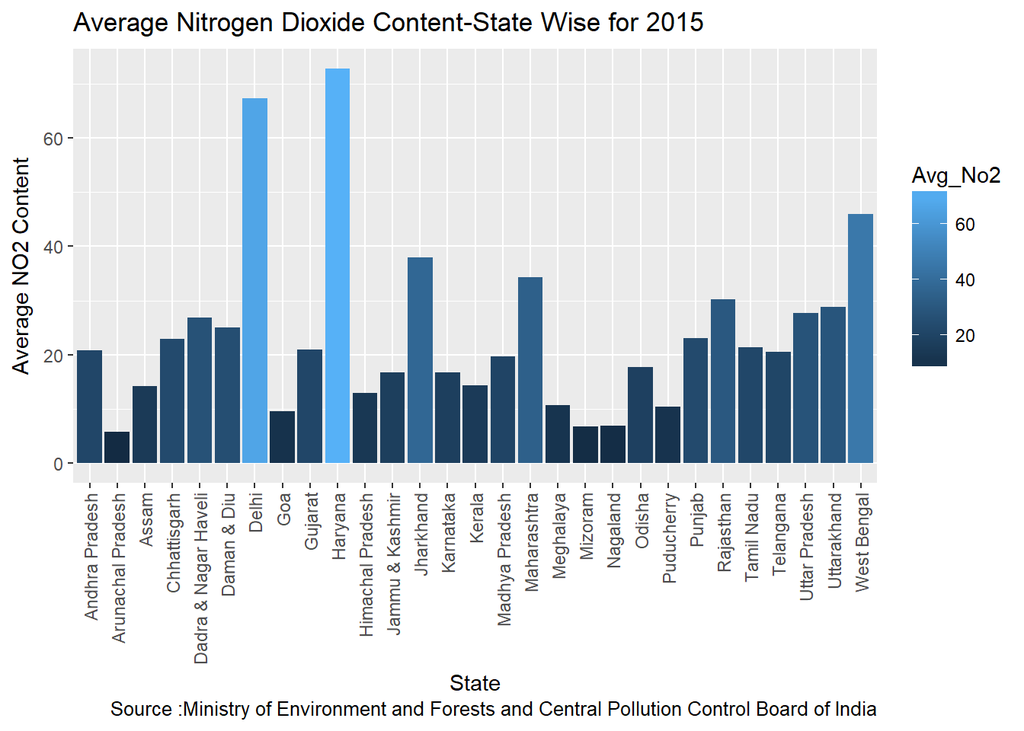

```r
ggplot(by_state_wise_2015,aes(x=state,y=Avg_No2,fill=Avg_No2)) +
  geom_bar(stat="identity") +
  theme(axis.text.x=element_text(angle=90,hjust=1,vjust=0.5)) +
  ggtitle("Average Nitrogen Dioxide Content-State Wise for 2015") +
  xlab(label="State") +
  ylab(label="Average NO2 Content") +
  labs(caption="Source :Ministry of Environment and Forests and Central Pollution Control Board of India")
```

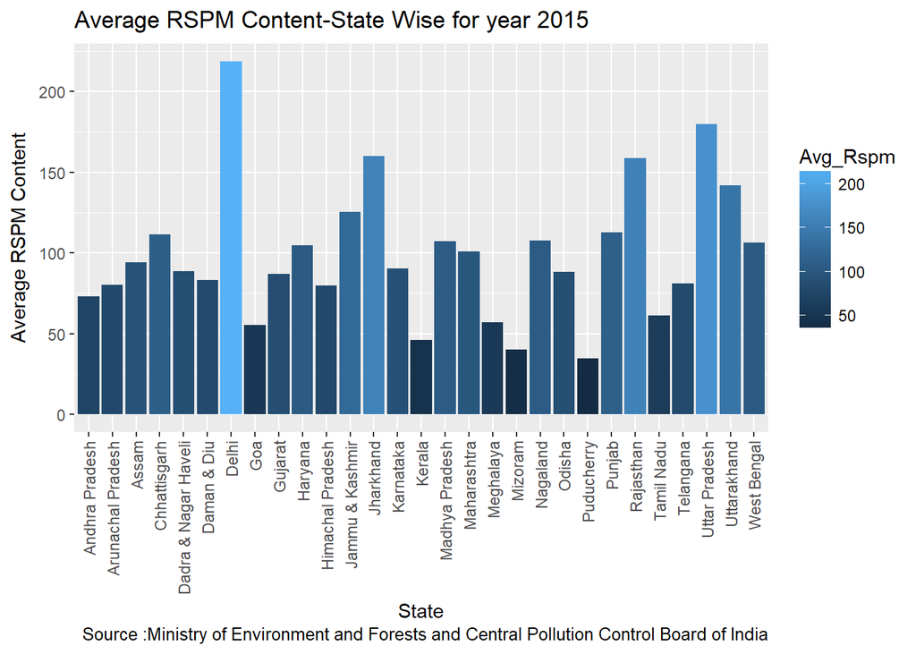

```r
ggplot(by_state_wise_2015,aes(x=state,y=Avg_Rspm,fill=Avg_Rspm)) +
  geom_bar(stat="identity") +
  theme(axis.text.x=element_text(angle=90,hjust=1,vjust=0.5)) +
  ggtitle("Average RSPM Content-State Wise for year 2015") +
  xlab(label="State") +
  ylab(label="Average RSPM Content") +
  labs(caption="Source :Ministry of Environment and Forests and Central Pollution Control Board of India")
```

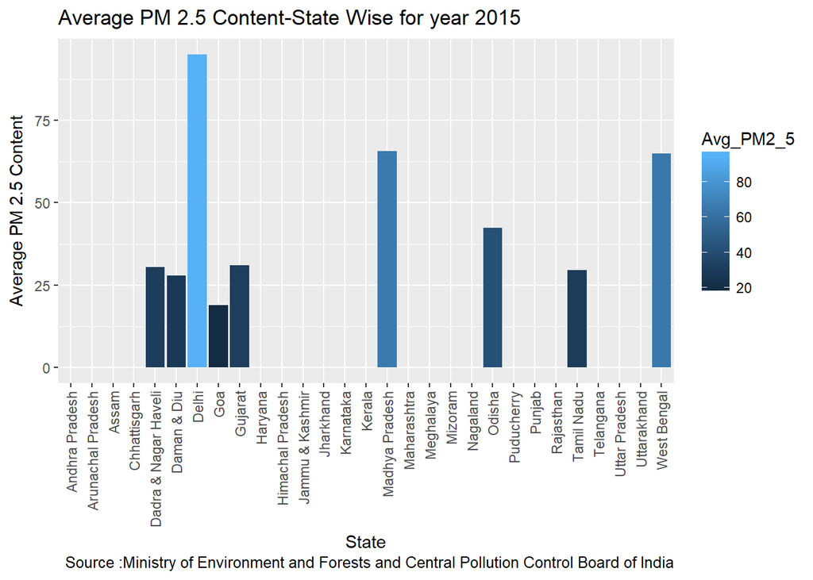

```r
ggplot(by_state_wise_2015,aes(x=state,y=Avg_PM2_5,fill=Avg_PM2_5)) +
  geom_bar(stat="identity") +
  theme(axis.text.x=element_text(angle=90,hjust=1,vjust=0.5)) +
  ggtitle("Average PM 2.5 Content-State Wise for year 2015") +
  xlab(label="State") +
  ylab(label="Average PM 2.5 Content") +
  labs(caption="Source :Ministry of Environment and Forests and Central Pollution Control Board of India")
```

# Insight

#### As seen from above plots, we will be analysising the trends of following states

- Delhi
- Haryana
- Uttar Pradesh

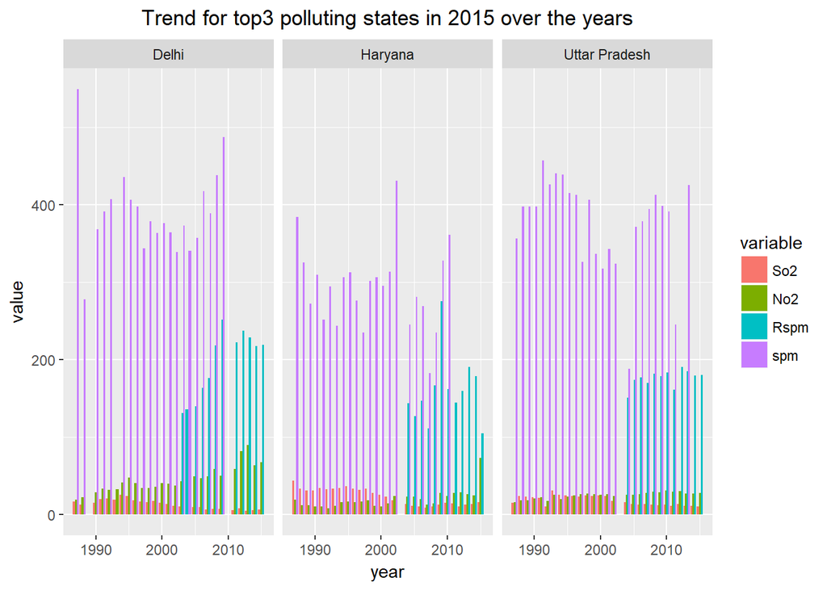

```r
target=c("Delhi","Haryana","Uttar Pradesh")
State_Year_Wise =airquality%>%filter(state %in% target)%>%group_by(state,year) %>%summarise(So2=mean(so2,na.rm=TRUE),
                                               No2=mean(no2,na.rm=TRUE),
                                               Rspm=mean(rspm,na.rm=TRUE),
                                               spm=mean(spm,na.rm=TRUE))
State_Year_Wise.long =melt(State_Year_Wise,id=c("year","state"),measure=c("So2","No2","Rspm","spm"),na.rm=TRUE)
State_Year_Wise_RawData =airquality%>%filter(state %in% target)%>%group_by(state,year) %>%summarise(So2=mean(so2,na.rm=TRUE),
                                               No2=mean(no2,na.rm=TRUE),
                                               Rspm=mean(rspm,na.rm=TRUE),
                                               spm=mean(spm,na.rm=TRUE))

bang_Year_Wise=airquality%>%filter(location== 'Bangalore')%>%group_by(year) %>%summarise(So2=mean(so2,na.rm=TRUE),
                                               No2=mean(no2,na.rm=TRUE),
                                               Rspm=mean(rspm,na.rm=TRUE),
                                               spm=mean(spm,na.rm=TRUE))

bang_Year_Wise.long =melt(bang_Year_Wise,id=c("year"),measure=c("So2","No2","Rspm","spm"),na.rm=TRUE)

ggplot(State_Year_Wise.long, aes(x=year, y=value, fill=variable))+geom_bar(stat='identity', position='dodge')+facet_wrap(~state)  +  ggtitle("Trend for top3 polluting states in 2015 over the years") +
  theme(plot.title = element_text(hjust = 0.5))
```

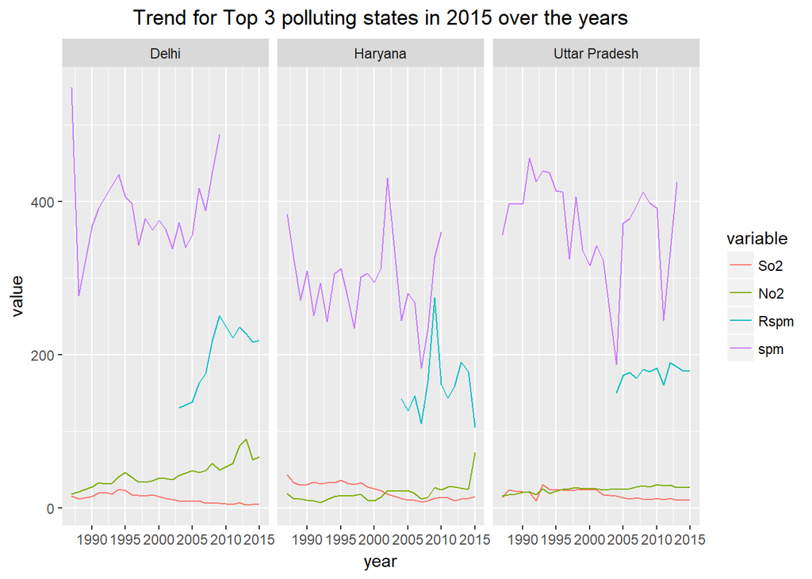

```r
ggplot(State_Year_Wise.long, aes(x=year, y=value, colour=variable))+geom_line() +facet_wrap(~state)  +  ggtitle("Trend for Top 3 polluting states in 2015 over the years") +
  theme(plot.title = element_text(hjust = 0.5))
```

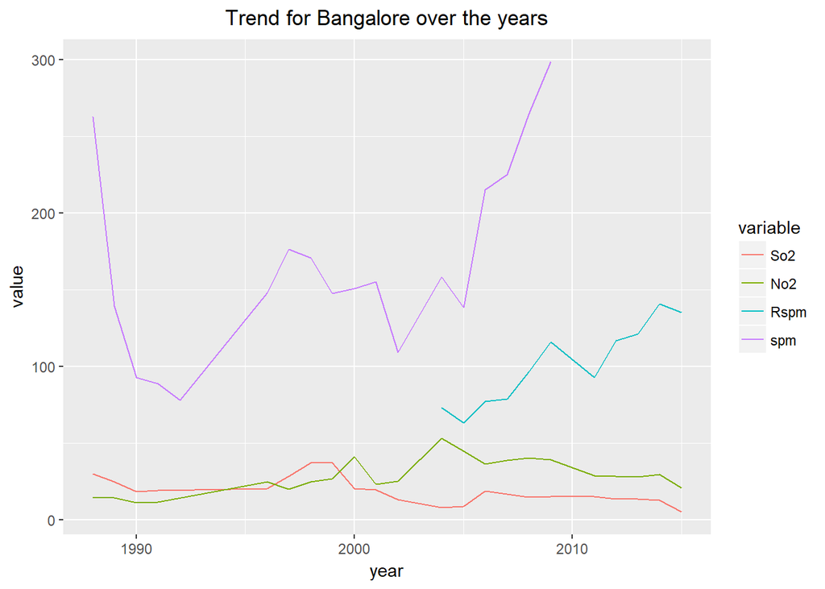

```r
ggplot(bang_Year_Wise.long, aes(x=year, y=value, colour=variable))+geom_line() +  ggtitle("Trend for Bangalore over the years") +
  theme(plot.title = element_text(hjust = 0.5))
```

# Predict

- We will predict the air pollution levels for Delhi for coming Diwali months as Delhi is the most polluted state in India

```r
Delhi_SO2 <-airquality%>%filter(state =='Delhi')%>%select(date,so2)
colnames(Delhi_SO2)=c('ds','y')
library(StanHeaders)
library(prophet)
m=prophet(Delhi_SO2)
```

```
## Disabling daily seasonality. Run prophet with daily.seasonality=TRUE to override this.
```

```
## Initial log joint probability = -21.79
## Optimization terminated normally:
##   Convergence detected: relative gradient magnitude is below tolerance
```

```r
future=make_future_dataframe(m,periods=700)
forecast=predict(m,future)
forecast=forecast%>%filter(ds > "2016-10-15")
Delhi_NO2 <-airquality%>%filter(state =='Delhi')%>%select(date,no2)
colnames(Delhi_NO2)=c('ds','y')
mno2=prophet(Delhi_NO2)
```

```
## Disabling daily seasonality. Run prophet with daily.seasonality=TRUE to override this.
```

```
## Initial log joint probability = -52.5932
## Optimization terminated normally:
##   Convergence detected: relative gradient magnitude is below tolerance
```

```r
future_no2=make_future_dataframe(m,periods=700)
forecast_no2=predict(mno2,future_no2)
forecast_no2=forecast_no2%>%filter(ds > "2016-10-15")
Delhi_RSPM <-airquality%>%filter(state =='Delhi')%>%select(date,rspm)
colnames(Delhi_RSPM)=c('ds','y')
m_RSPM=prophet(Delhi_RSPM)
```

```
## Disabling daily seasonality. Run prophet with daily.seasonality=TRUE to override this.
```

```
## Initial log joint probability = -55.0588
## Optimization terminated normally:
##   Convergence detected: relative gradient magnitude is below tolerance
```

```r
future_RSPM=make_future_dataframe(m_RSPM,periods=700)
forecast_RSPM=predict(m_RSPM,future_RSPM)
forecast_RSPM=forecast_RSPM%>%filter(ds > "2016-10-15")

Delhi_SPM <-airquality%>%filter(state =='Delhi')%>%select(date,spm)
colnames(Delhi_SPM)=c('ds','y')
m_SPM=prophet(Delhi_SPM)
```

```
## Disabling daily seasonality. Run prophet with daily.seasonality=TRUE to override this.
```

```
## Initial log joint probability = -100.093
## Optimization terminated normally:
##   Convergence detected: relative gradient magnitude is below tolerance
```

```r
future_SPM=make_future_dataframe(m_SPM,periods=700)
forecast_SPM=predict(m_SPM,future_SPM)
forecast_SPM=forecast_SPM%>%filter(ds > "2016-10-15")

Delhi_PM <-airquality%>%filter(state =='Delhi')%>%select(date,pm2_5)
colnames(Delhi_PM)=c('ds','y')
m_PM=prophet(Delhi_PM)
```

```
## Disabling yearly seasonality. Run prophet with yearly.seasonality=TRUE to override this.
```

```
## Disabling daily seasonality. Run prophet with daily.seasonality=TRUE to override this.
```

```
## Initial log joint probability = -6.79335
## Optimization terminated normally:
##   Convergence detected: relative gradient magnitude is below tolerance
```

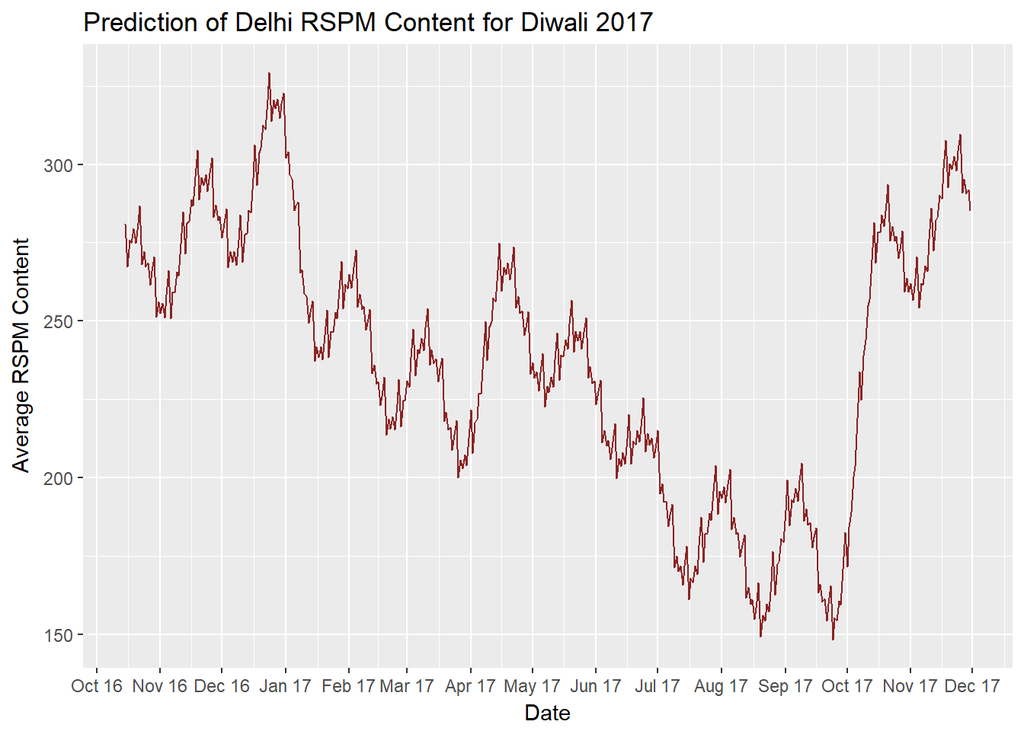

```r
future_PM=make_future_dataframe(m_PM,periods=700)
forecast_PM=predict(m_PM,future_PM)
forecast_PM=forecast_PM%>%filter(ds > "2016-10-15")

forecast_RSPM$ds=as.Date(forecast_RSPM$ds)
forecast$ds=as.Date(forecast$ds)
forecast_SPM$ds=as.Date(forecast_SPM$ds)
forecast_PM$ds=as.Date(forecast_PM$ds)
forecast_no2$ds=as.Date(forecast_no2$ds)
ggplot(data = forecast_RSPM, aes(x=ds, y=yhat))+geom_line(color='brown4') + ggtitle("Prediction of Delhi RSPM Content for Diwali 2017") +
  xlab(label="Date") +
  ylab(label="Average RSPM Content") +scale_x_date(date_labels="%b %y",date_breaks  ="1 month")
```

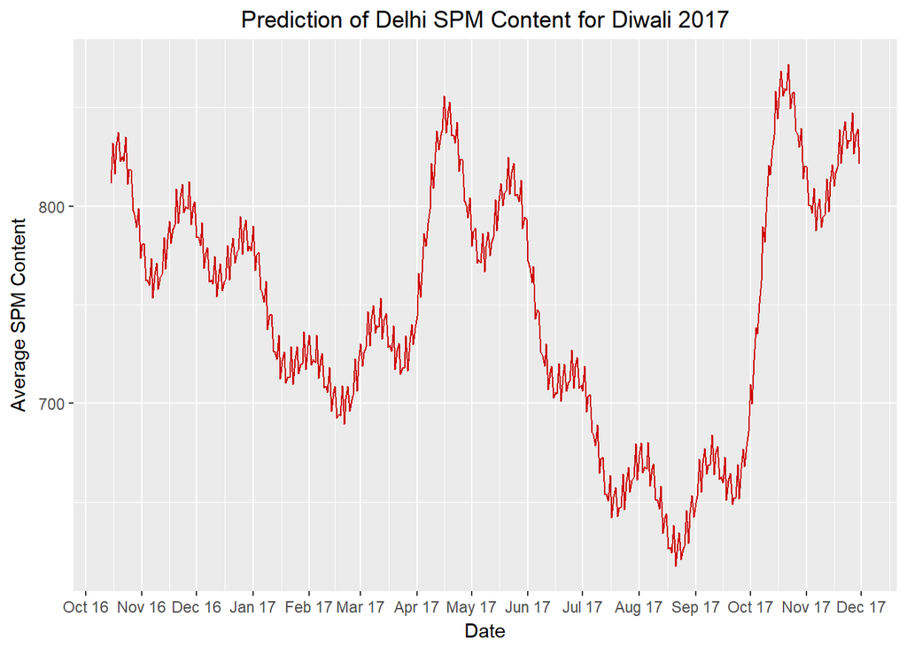

```r
ggplot(data = forecast_SPM, aes(x=ds, y=yhat))+geom_line(color='red3') + ggtitle("Prediction of Delhi SPM Content for Diwali 2017") +
  xlab(label="Date") +
  ylab(label="Average SPM Content") +scale_x_date(date_labels="%b %y",date_breaks  ="1 month")+theme(plot.title = element_text(hjust = 0.5))
```

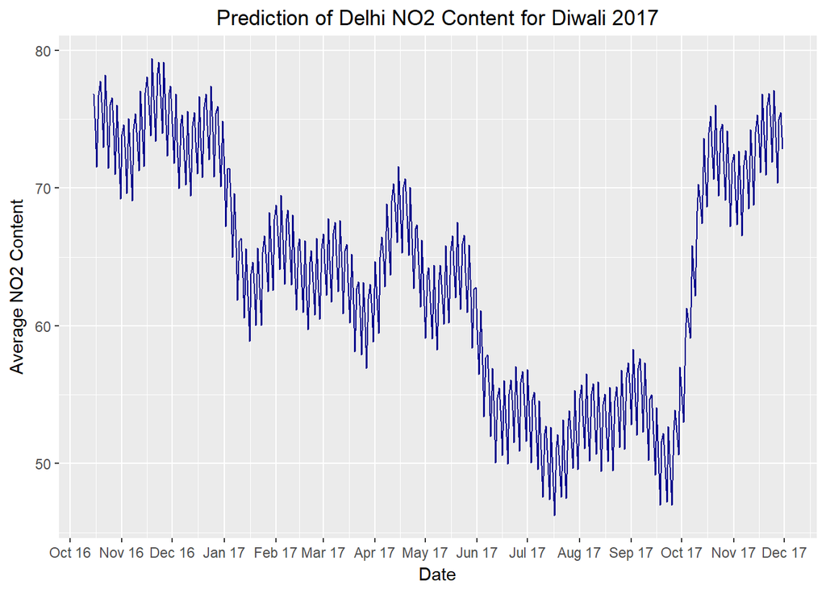

```r
ggplot(data = forecast_no2, aes(x=ds, y=yhat))+geom_line(color='blue4') + ggtitle("Prediction of Delhi NO2 Content for Diwali 2017") +
  xlab(label="Date") +
  ylab(label="Average NO2 Content") +scale_x_date(date_labels="%b %y",date_breaks  ="1 month") +theme(plot.title = element_text(hjust = 0.5))
```

[figure not shown]

```r
ggplot(data = forecast, aes(x=ds, y=yhat))+geom_line(color='darkorange3') + ggtitle("Prediction of Delhi RSPM Content for Diwali 2017") +
  xlab(label="Date") +
  ylab(label="Average so2 Content") +scale_x_date(date_labels="%b %y",date_breaks  ="1 month") +theme(plot.title = element_text(hjust = 0.5))
```

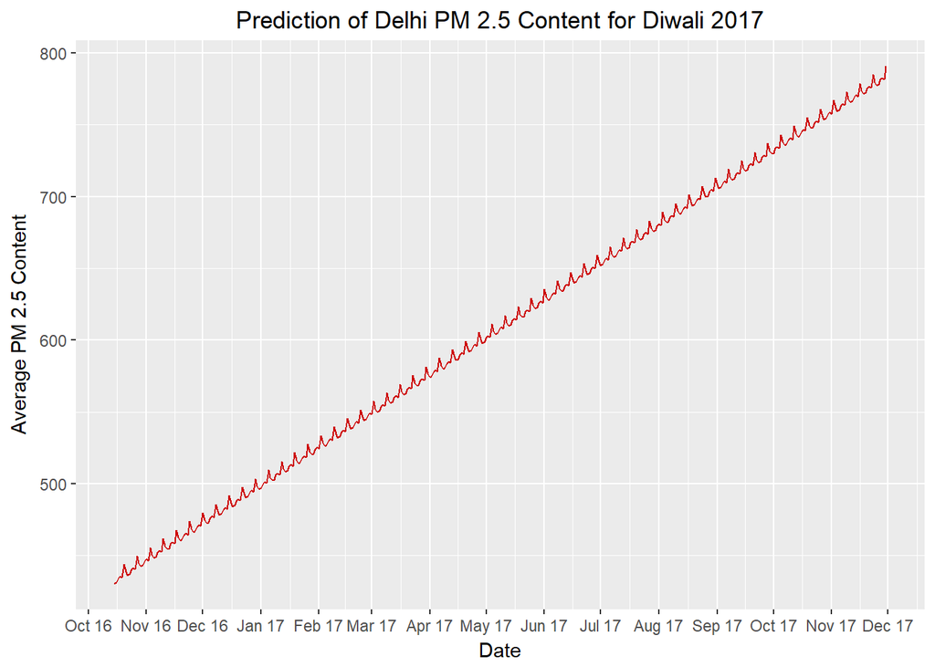

```r
ggplot(data = forecast_PM, aes(x=ds, y=yhat))+geom_line(color='red3') + ggtitle("Prediction of Delhi PM 2.5 Content for Diwali 2017") +
  xlab(label="Date") +
  ylab(label="Average PM 2.5 Content") +scale_x_date(date_labels="%b %y",date_breaks  ="1 month") +theme(plot.title = element_text(hjust = 0.5))
```